# GLM I - Multinomial Data

## Multinomial Logit Model (Chapter 7)

## Set Up

- (Note we are skipping Chapter 6)
- A multinomial distribution is an extension of the binomial where the response can take more than two values.
- Let \(Y_i\) be a random variable that falls into one of a finite number of categories (1, 2 … *J*)
- \(p_{ij} = P(Y_i = j)\) and \(\sum_{j=1}^J p_{ij} = 1\)
- When does this become the binary case?
- Let \(Y_{ij}\) by the number of observations that fall into category *j* for observation *i*. \(n_i = \sum_j Y_{ij}\)
- What are \(n_i\) and \(J\) for Bernoulli?

\[ P(Y_{i1} = y_{i1}, ..., Y_{iJ} = y_{iJ}) = \frac{n_i}{y_{i1}!...y_{iJ}!} p_{i1}^{y_{i1}} ... p_{iJ}^{y_{iJ}} \]

- ordinal vs multinomial data

## Election Study :)

- collapse party into 3 categories and create numeric value for income (code not shown)

```r
summary(rnes96)
```

|  | party | income | education | age |
| --- | --- | --- | --- | --- |
|  | Democrat :380 | Min. : 1.50 | MS : 13 | Min. :19.00 |
|  | Independent:239 | 1st Qu.: 23.50 | HSdrop: 52 | 1st Qu.:34.00 |
|  | Republican :325 | Median : 37.50 | HS :248 | Median :44.00 |
|  | NA | Mean : 46.58 | Coll :187 | Mean :47.04 |
|  | NA | 3rd Qu.: 67.50 | CCdeg : 90 | 3rd Qu.:58.00 |
|  | NA | Max. :115.00 | BAdeg :227 | Max. :91.00 |
|  | NA | NA | MAdeg :127 | NA |

## Some Graphs - Party by Education

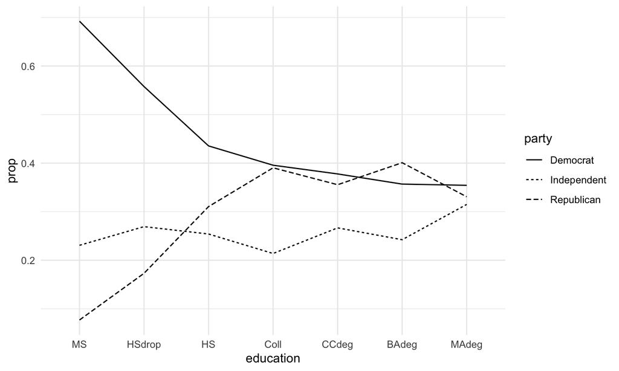

## Some more graphs - Party by Income

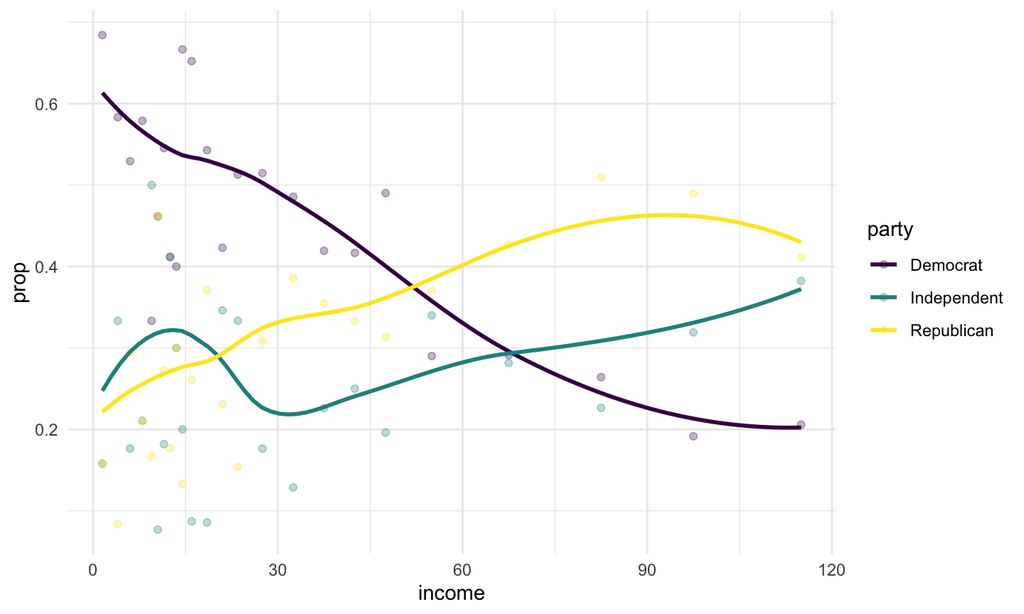

## Fit the Model

```r
library(nnet)
mmod <- multinom(party ~ age + education + income, rnes96)
mmodi <- step(mmod, trace = 0) # we can also use deviance etc.
```

```
## trying - age
## trying - education
## trying - income
## trying - age
## trying - income
## trying - income
```

## Lets just look at income

```r
fake_data <- data.frame(income = 1:110)
fake_data <- cbind(fake_data, predict(mmodi, fake_data, type = "probs"))
summary(fake_data)
```

|  | income | Democrat | Independent | Republican |
| --- | --- | --- | --- | --- |
|  | Min. : 1.00 | Min. :0.1815 | Min. :0.1838 | Min. :0.2305 |
|  | 1st Qu.: 28.25 | 1st Qu.:0.2606 | 1st Qu.:0.2291 | 1st Qu.:0.2999 |
|  | Median : 55.50 | Median :0.3591 | Median :0.2708 | Median :0.3701 |
|  | Mean : 55.50 | Mean :0.3678 | Mean :0.2657 | Mean :0.3665 |
|  | 3rd Qu.: 82.75 | 3rd Qu.:0.4710 | 3rd Qu.:0.3047 | 3rd Qu.:0.4346 |
|  | Max. :110.00 | Max. :0.5857 | Max. :0.3289 | Max. :0.4897 |

## Income as a graph

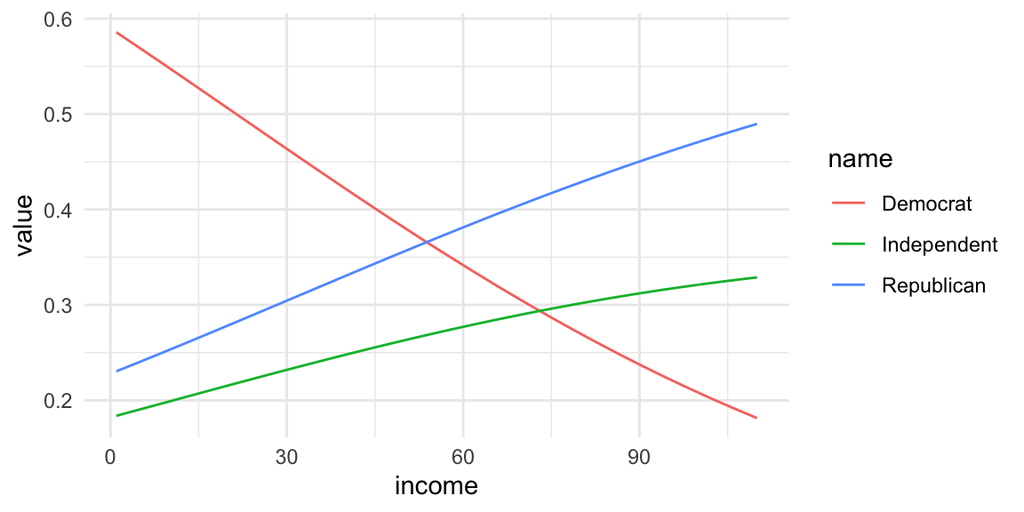

```r
fake_data %>%
  tidyr::pivot_longer(-income) %>%
  ggplot(aes( x = income, y = value, color = name)) +
  geom_line()
```

- what will be chosen as the prediction at different income levels?
- Will independent ever be chosen?

## Interpret Coefficients

```r
broom::tidy(mmodi)
```

| y.level | term | estimate | std.error | statistic | p.value |
| --- | --- | --- | --- | --- | --- |
| Independent | (Intercept) | -1.1749331 | 0.1536103 | -7.648789 | 0 |
| Independent | income | 0.0160868 | 0.0028497 | 5.645021 | 0 |
| Republican | (Intercept) | -0.9503591 | 0.1416859 | -6.707505 | 0 |
| Republican | income | 0.0176646 | 0.0026525 | 6.659513 | 0 |

## Interpret Coefficients

\[ \eta_{ij} = x^T_i \beta_j = log(\frac{p_{ij}}{p_{i1}}) \]

- One category is baseline such that:

\[ p_{i1} = 1 - \sum^J_{j = 2} p_{ij} \]

- Therefore:

\[ p_{ij} = \frac{exp(\eta_{ij})}{1 + \sum^J_{j=2} exp(\eta_{ij})} \\ = \frac{exp(\eta_{ij})}{\sum^J_{j=1} exp(\eta_{ij})} \] Why?

## Interpret Coefficients (intercept)

```r
cc <- c(0,-1.17493,-0.95036)
exp(cc)/sum(exp(cc))
```

```
## [1] 0.5898166 0.1821593 0.2280242
```

```r
predict(mmodi,data.frame(income=0),type="probs")
```

```
##    Democrat Independent  Republican
##   0.5898168   0.1821588   0.2280244
```

## Interpret Coefficients

```r
broom::tidy(mmodi, exponentiate = TRUE)
```

| y.level | term | estimate | std.error | statistic | p.value |
| --- | --- | --- | --- | --- | --- |
| Independent | (Intercept) | 0.3088396 | 0.1536103 | -7.648789 | 0 |
| Independent | income | 1.0162169 | 0.0028497 | 5.645021 | 0 |
| Republican | (Intercept) | 0.3866022 | 0.1416859 | -6.707505 | 0 |
| Republican | income | 1.0178215 | 0.0026525 | 6.659513 | 0 |

- What about log odds from independent to republican?

## Hierarchical or Nested Responses

## Set Up

- Live births with deformations of the central nervous system

```r
data(cns, package="faraway")
cns %>% summary
```

|  | Area | NoCNS | An | Sp | Other | Water | Work |
| --- | --- | --- | --- | --- | --- | --- | --- |
|  | Cardiff :2 | Min. : 1515 | Min. : 1.00 | Min. : 5.00 | Min. : 0.00 | Min. : 39.00 | Manual :8 |
|  | GlamorganC :2 | 1st Qu.: 2386 | 1st Qu.: 5.00 | 1st Qu.: 8.75 | 1st Qu.: 1.75 | 1st Qu.: 72.75 | NonManual:8 |
|  | GlamorganE :2 | Median : 4350 | Median : 9.00 | Median :13.50 | Median : 4.00 | Median : 97.50 | NA |
|  | GlamorganW :2 | Mean : 5241 | Mean :16.00 | Mean :21.38 | Mean : 6.00 | Mean : 94.00 | NA |
|  | MonmouthOther:2 | 3rd Qu.: 7901 | 3rd Qu.:26.25 | 3rd Qu.:30.75 | 3rd Qu.:10.50 | 3rd Qu.:113.00 | NA |
|  | MonmouthV :2 | Max. :13217 | Max. :55.00 | Max. :71.00 | Max. :19.00 | Max. :161.00 | NA |
|  | (Other) :4 | NA | NA | NA | NA | NA | NA |

## Outcome

- 4 Groups, but really:

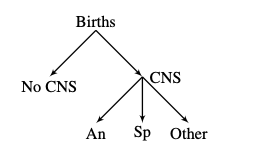

## Modeling - Equations

\[ p_{i1}^{y_{i1}}p_{i2}^{y_{i2}}p_{i3}^{y_{i3}}p_{i4}^{y_{i4}} \] create a new variables \(p_{ic} = p_{i2} + p_{i3} + p_{i4}\) - what does this represent?

Rewrite above as:

\[ p_{i1}^{y_{i1}}p_{ic}^{y_{i2} + y_{i3} + y_{i4}} \left(\frac{p_{i2}}{p_{ic}}\right)^{y_{i2}} \left(\frac{p_{i3}}{p_{ic}}\right)^{y_{i3}} \left(\frac{p_{i4}}{p_{ic}}\right)^{y_{i4}} \] - first part is now a binomial and second part of the product is multinomial likelihood conditional on presence of CNS

## Modeling - Binomial Part

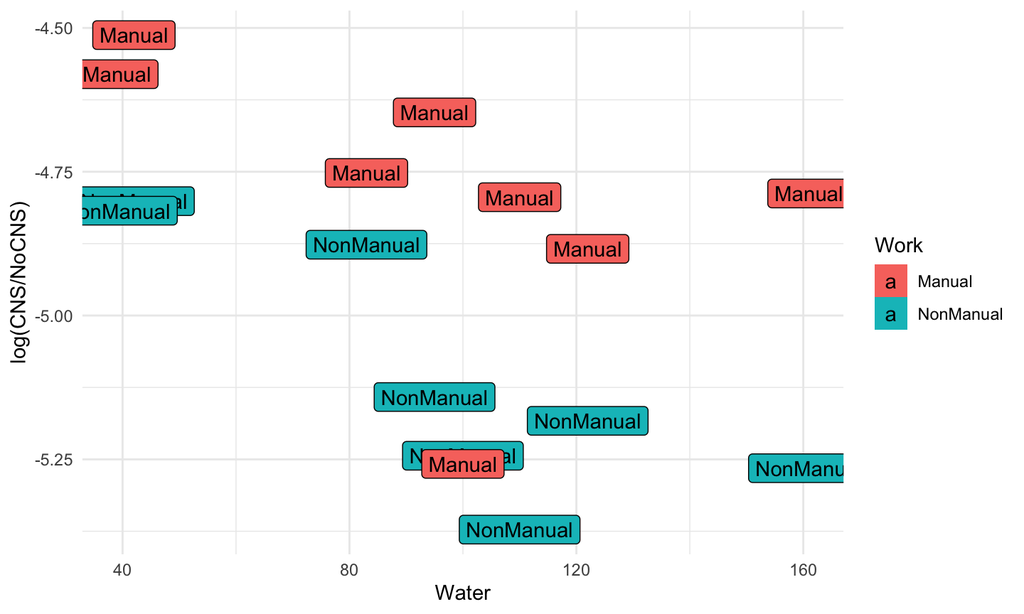

```r
cns$CNS <- cns$An+cns$Sp+cns$Other
ggplot(cns, aes(x = Water, y = log(CNS/NoCNS))) +
  geom_label(aes(label = Work, fill = Work))
```

## Fitting Model

```r
# issue fitting - Water and Area are linked
full_mod <- glm(cbind(CNS, NoCNS) ~ Water + Work + Area, data = cns, family = binomial)
mod1 <- glm(cbind(CNS, NoCNS) ~ Water + Work, data = cns, family = binomial)
mod2 <- glm(cbind(CNS, NoCNS) ~ Area + Work, data = cns, family = binomial)

AIC(mod1)
```

```
## [1] 102.4891
```

```r
AIC(mod2)
```

```
## [1] 105.2034
```

## Explore Residuals

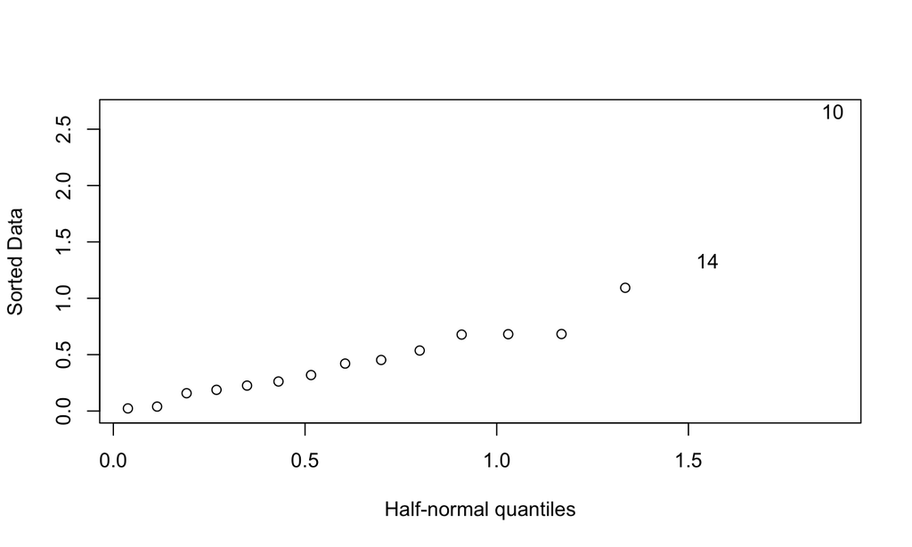

## Explore Residuals further

|  | Area | NoCNS | An | Sp | Other | Water | Work | CNS |
| --- | --- | --- | --- | --- | --- | --- | --- | --- |
| 10 | Newport | 4610 | 3 | 15 | 6 | 100 | Manual | 24 |

```r
mod1_no_out <- update(mod1, data = cns[-10, ])
glance(mod1)
```

| null.deviance | df.null | logLik | AIC | BIC | deviance | df.residual | nobs |
| --- | --- | --- | --- | --- | --- | --- | --- |
| 41.04749 | 15 | -48.24454 | 102.4891 | 104.8068 | 12.36281 | 13 | 16 |

```r
glance(mod1_no_out)
```

| null.deviance | df.null | logLik | AIC | BIC | deviance | df.residual | nobs |
| --- | --- | --- | --- | --- | --- | --- | --- |
| 34.73413 | 14 | -41.93872 | 89.87743 | 92.00159 | 4.768858 | 12 | 15 |

- no real difference in estimates so lets keep it in

```r
tidy(mod1)
tidy(mod1_no_out)
```

[output not shown]

## Binomial model - interpertation

```r
tidy(mod1, exponentiate = T)
```

| term | estimate | std.error | statistic | p.value |
| --- | --- | --- | --- | --- |
| (Intercept) | 0.0118838 | 0.0897889 | -49.366678 | 0.0000000 |
| Water | 0.9967409 | 0.0009684 | -3.370920 | 0.0007492 |
| WorkNonManual | 0.7124413 | 0.0970943 | -3.492046 | 0.0004793 |

- increase in 100 water hardness

```r
exp(mod1$coefficients['Water']*100)
```

```
##     Water
## 0.7214867
```

## Create Multinomial

```
## Call:
## multinom(formula = cbind(An, Sp, Other) ~ Water + Work, data = cns)
##
## Coefficients:
##       (Intercept)        Water WorkNonManual
## Sp      0.3752018 -0.001297048     0.1157557
## Other  -1.1225496  0.002182689    -0.2702791
##
## Std. Errors:
##       (Intercept)       Water WorkNonManual
## Sp      0.1900329 0.002032944     0.2086875
## Other   0.2795628 0.002896841     0.3247247
##
## Residual Deviance: 1371.524
## AIC: 1383.524
```

## Create Multinomial - step

```
## Start:  AIC=1383.52
## cbind(An, Sp, Other) ~ Water + Work
##
## trying - Water
## trying - Work
##         Df      AIC
## - Water  4 1381.124
## - Work   4 1381.161
## <none>   6 1383.524
##
## Step:  AIC=1381.12
## cbind(An, Sp, Other) ~ Work
##
## trying - Work
##        Df      AIC
## - Work  2 1378.455
## <none>  4 1381.124
##
## Step:  AIC=1378.45
## cbind(An, Sp, Other) ~ 1
```

## Multi-step Output

```
## Call:
## multinom(formula = cbind(An, Sp, Other) ~ 1, data = cns)
##
## Coefficients:
##       (Intercept)
## Sp      0.2896333
## Other  -0.9808293
##
## Std. Errors:
##       (Intercept)
## Sp     0.08264518
## Other  0.11967839
##
## Residual Deviance: 1374.455
## AIC: 1378.455
```

## Show Rates

```r
cc <- c(0, as.vector(coef(cmmod)))
names(cc) <- c("An","Sp","Other")
exp(cc)/sum(exp(cc))
```

```
##        An        Sp     Other
## 0.3688761 0.4927954 0.1383285
```

```r
colSums(cns %>% select(An, Sp, Other ))/sum(cns$CNS)
```

```
##        An        Sp     Other
## 0.3688761 0.4927954 0.1383285
```

## Multinomial model on all the data

```
## Call:
## multinom(formula = cbind(NoCNS, An, Sp, Other) ~ Water + Work,
##     data = cns)
##
## Coefficients:
##       (Intercept)         Water WorkNonManual
## An      -5.455142 -0.0029088415    -0.3638609
## Sp      -5.071037 -0.0043231569    -0.2435803
## Other   -6.594755 -0.0005127307    -0.6420771
##
## Std. Errors:
##       (Intercept)       Water WorkNonManual
## An      0.1478021 0.001586305     0.1604950
## Sp      0.1267049 0.001387540     0.1348058
## Other   0.2456265 0.002550003     0.2834179
##
## Residual Deviance: 9390.965
## AIC: 9408.965
```

## Ordinal Multinomial Responses

## Setup

- J ordered categories with ordinal response

```r
letter_samp <- sample(LETTERS[1:5], 100, replace = T)
table(letter_samp)
```

| A | B | C | D | E |
| --- | --- | --- | --- | --- |
| 21 | 15 | 27 | 19 | 18 |

```r
cumsum(table(letter_samp))
```

```
##   A   B   C   D   E
##  21  36  63  82 100
```

- \(\gamma_{ij} = P(Y_i \leq j)\):

```
##    A    B    C    D    E
## 0.21 0.36 0.63 0.82 1.00
```

## Link Functions

- \(\theta\) does not depend on predictors \(x\)
- \(\beta\) does not depend on categories

\[ g(\gamma_{ij}) = \theta_j - x_i^T\beta \] - link functions for \(g\) are logit, probit an cloglog

## Latent Variable interpertation

- Suppose there is a true continuous variable (\(Z_i\)) that we only observe through a discritized version (\(Y_i\)) where \(Y_i = j\) is observed if \(\theta_{j-1} < Z_i \leq \theta_j\).
- Suppose that \(Z_i - \beta^Tx_i\) has distribution \(F\) then:

\[ P(Y_i \leq j) = P(Z_i \leq \theta_j) = P(Z_i - \beta^Tx_i \leq \theta_j - \beta^Tx_i) = F(\theta_j - \beta^Tx_i) \] - Choosing different underlying latent variable distributions leads to different link functions

## Visualization

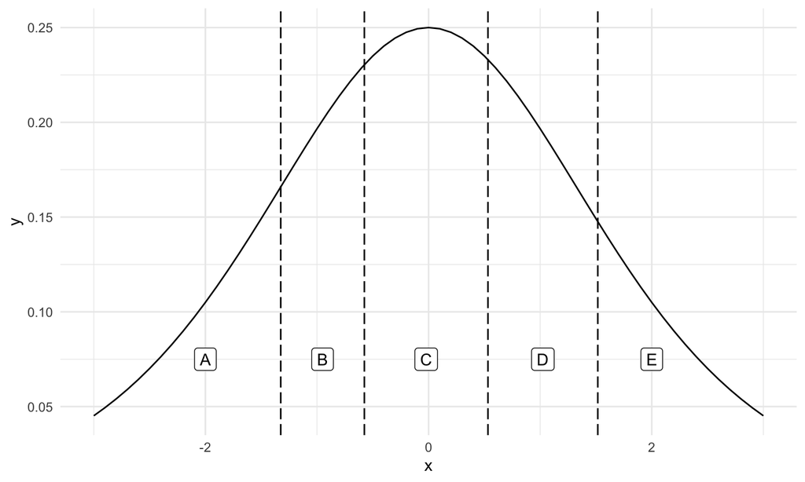

## Proportional Odds

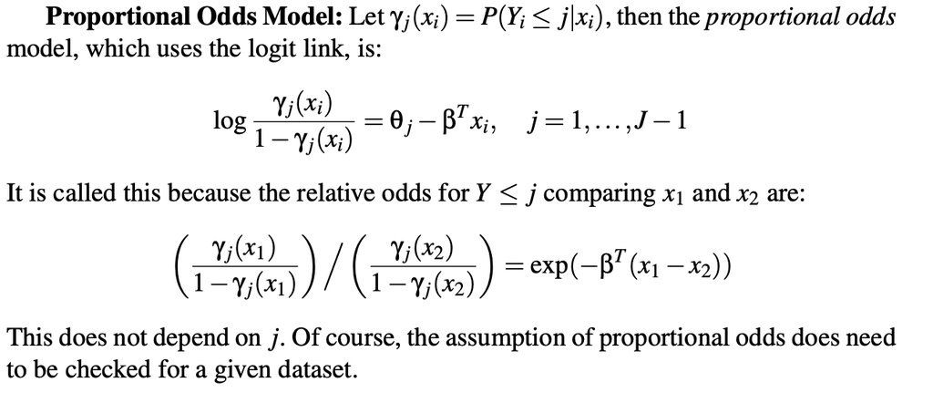

## Fitting a model

- All likelihood methods apply (deviance, AIC etc)

```r
library(MASS)
pomod <- polr(party ~ age + education + income, rnes96)
pomodi <- step(pomod)
```

```
## Start:  AIC=2004.21
## party ~ age + education + income
##
##             Df    AIC
## - education  6 2002.8
## <none>         2004.2
## - age        1 2004.4
## - income     1 2038.6
##
## Step:  AIC=2002.83
## party ~ age + income
##
##          Df    AIC
## - age     1 2001.4
## <none>      2002.8
## - income  1 2047.2
##
## Step:  AIC=2001.36
## party ~ income
##
##          Df    AIC
## <none>      2001.4
## - income  1 2045.3
```

## Check prop odds

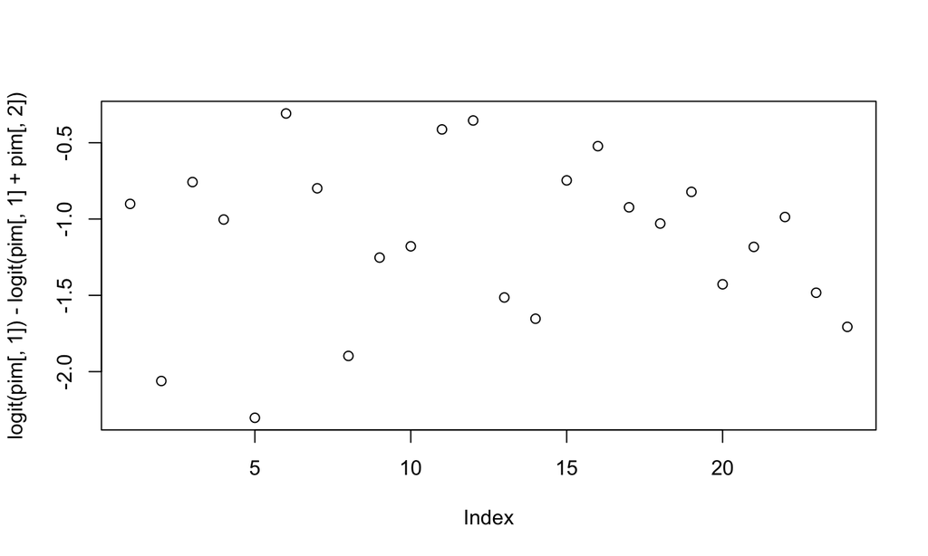

## Interpertation

```
##
## Re-fitting to get Hessian
```

```
## Call:
## polr(formula = party ~ income, data = rnes96)
##
## Coefficients:
##          Value Std. Error t value
## income 0.01312   0.001971   6.657
##
## Intercepts:
##                        Value   Std. Error t value
## Democrat|Independent    0.2091  0.1123     1.8627
## Independent|Republican  1.2916  0.1201    10.7526
##
## Residual Deviance: 1995.363
## AIC: 2001.363
```

- We can say that the odds of moving from Democrat to Independent/Republican category (or from Democrat/Independent to Republican) increase by a factor of exp(0.013120) = 1.0132 as income increases by one unit ($1000)

## Predicted Probs

income = 0, Dem

```r
ilogit(0.209)
```

```
## [1] 0.5520606
```

income = 0, Ind

```r
ilogit(1.292)-ilogit(0.209)
```

```
## [1] 0.2324249
```

## Generalization

- move to book if we get here